# Notebook 03 – Solutions

## Getting Started

Before running this notebook, select “Session > Restart R and Clear Output” in the menu above to start a new R session. This will clear any old data sets and give us a blank slate to start with.

After starting a new session, run the following code chunk to load the libraries and data that we will be working with today.

I have set the options `include=FALSE` and `message=FALSE` to avoid cluttering the solutions with all the output from this code.

## Practice

### Cities Data

To further practice the Grammar of Graphics, we will work with the largest cities data set.

```r
cities <- read_csv(file.path("data", "largest_cities.csv"))
cities
```

```
## # A tibble: 81 × 26
##    name        country    city_definition population city_pop city_area metro_pop
##    <chr>       <chr>      <chr>                <dbl>    <dbl>     <dbl>     <dbl>
##  1 Tokyo       Japan      Metropolis pre…       37.4    13.5       2191      37.3
##  2 Delhi       India      National capit…       28.5    16.8       1484      29
##  3 Shanghai    China      Municipality          25.6    24.2       6341      NA
##  4 São Paulo   Brazil     Municipality          21.6    12.3       1521      21.7
##  5 Mexico City Mexico     City-state            21.6     8.92      1485      20.9
##  6 Cairo       Egypt      Urban governor…       20.1     9.5       3085      NA
##  7 Mumbai      India      Municipality          20.0    12.5        603      24.4
##  8 Beijing     China      Municipality          19.6    21.7      16411      NA
##  9 Dhaka       Bangladesh Capital city          19.6    14.4        338      14.5
## 10 Osaka       Japan      Designated city       19.3     2.72       225      19.3
## # … with 71 more rows, and 19 more variables: metro_area <dbl>,
## #   urban_pop <dbl>, urban_area <dbl>, wiki <chr>, country_code2 <chr>,
## #   country_code3 <chr>, country_name_official <chr>, continent <chr>,
## #   lon <dbl>, lat <dbl>, koppen_code <chr>, koppen_main <chr>, city <chr>,
## #   num <dbl>, cost_of_living <dbl>, cost_rent <dbl>, cost_groceries <dbl>,
## #   cost_restaurant <dbl>, local_pp <dbl>
```

Population numbers are given in millions and areas are given in square kilometers. The three different kinds of populations refer to different ways of describing what is included in a city. The variable `population` is a measurement from the UN (2018) that tries to consistently define the region of a city. More information is available in the U.N.’s World Urbanization Prospectus, which is available [here](https://population.un.org/wup/Publications/Files/WUP2018-Highlights.pdf). The other three measurements refer to:

- **city**: city proper, defined by local administrative boundaries
- **metro**: according to UNICEF, the Metro Region is an area “comprising the urban area as a whole and its primary commuter areas… In addition to the city proper, a metropolitan area includes both the surrounding territory with urban levels of residential density and some additional lower-density areas that are adjacent to and linked to the city.” See [UNICEF](https://www.unicef.org/sowc2012/statistics.php) for more information.
- **urban**: an area that consists of a “continuously built up land mass of urban development that is within a labor market (metropolitan area or metropolitan region) and contains no rural land”.

Several of the questions in this and the following notebooks concern the analysis of the relationship between these various definitions.

### Scatterplot

In the code below, write the code to produce a scatter plot with population on the x-axis and the city population on the y-axis. I have set `warning=FALSE` because there are some missing data values and it will be helpful to turn off the warnings about these data rows.

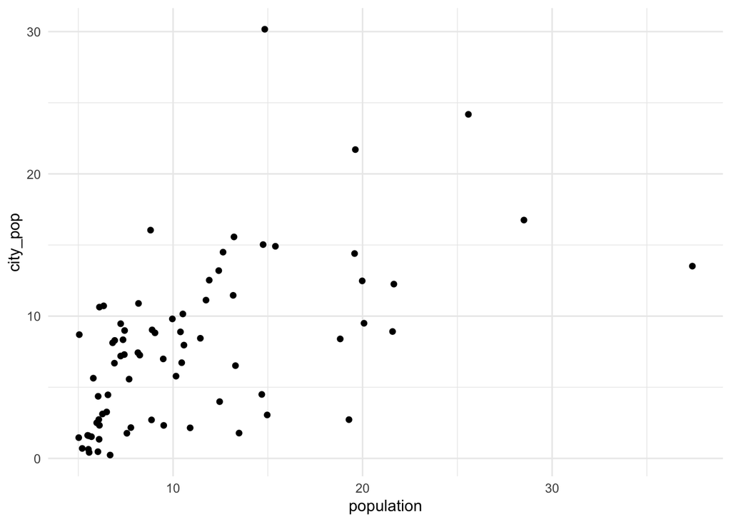

```r
cities %>%
  ggplot() +
    geom_point(aes(x = population, y = city_pop))
```

Now, in the code region below, produce a scatter plot with population on the x-axis and metro population on the y-axis.

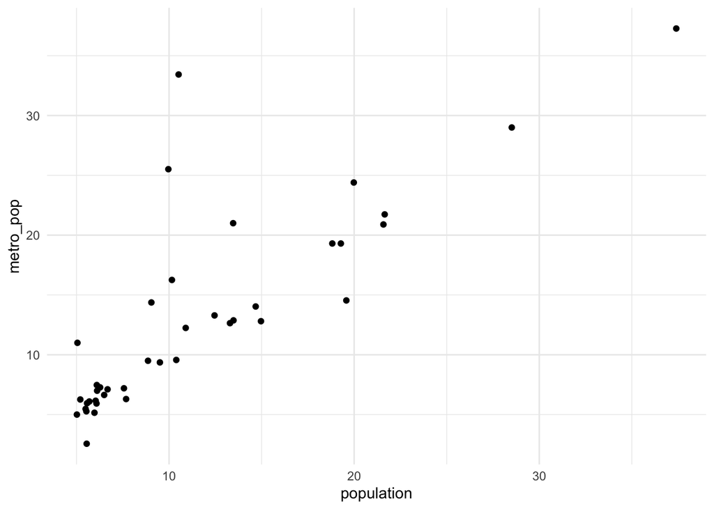

```r
cities %>%
  ggplot() +
    geom_point(aes(x = population, y = metro_pop))
```

Which of the two regional populations (metro or city) seem to more closely relate to the U.N.’s definition of a cities population (e.g., the `population` variable). **Answer**: The metropolitan population is much closer to the UN definition than the city population variable.

## Text Plot

Produce a plot with population on the x-axis and metro population on the y-axis and label each point with the city name.

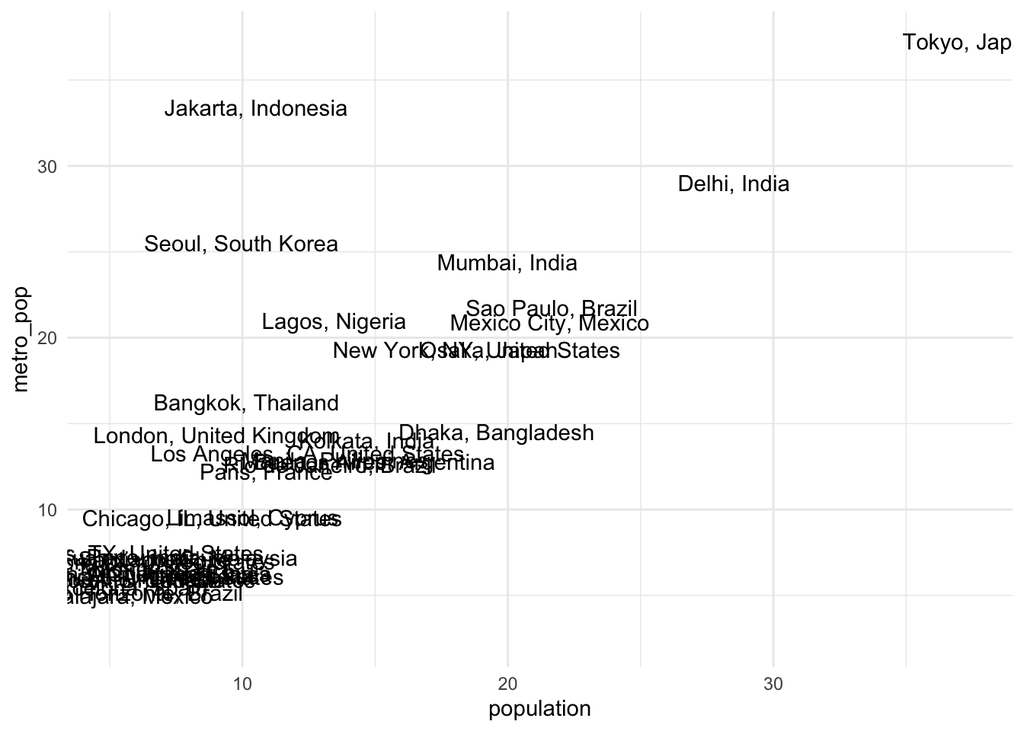

```r
cities %>%
  ggplot() +
    geom_text(aes(x = population, y = metro_pop, label = city))
```

What two cities seem to have the largest (absolute) discrepancy between their UN population and the metro population? **Answer**: Jakarta and Seoul seem to stand out the most (their metro populations are much larger than the offical UN population numbers).

Produce a plot with a text geometry where longitude (`lon`) is on the x-axis, latitude is on the y-axis (`lat`), and the labels are given by the city names (`name`).

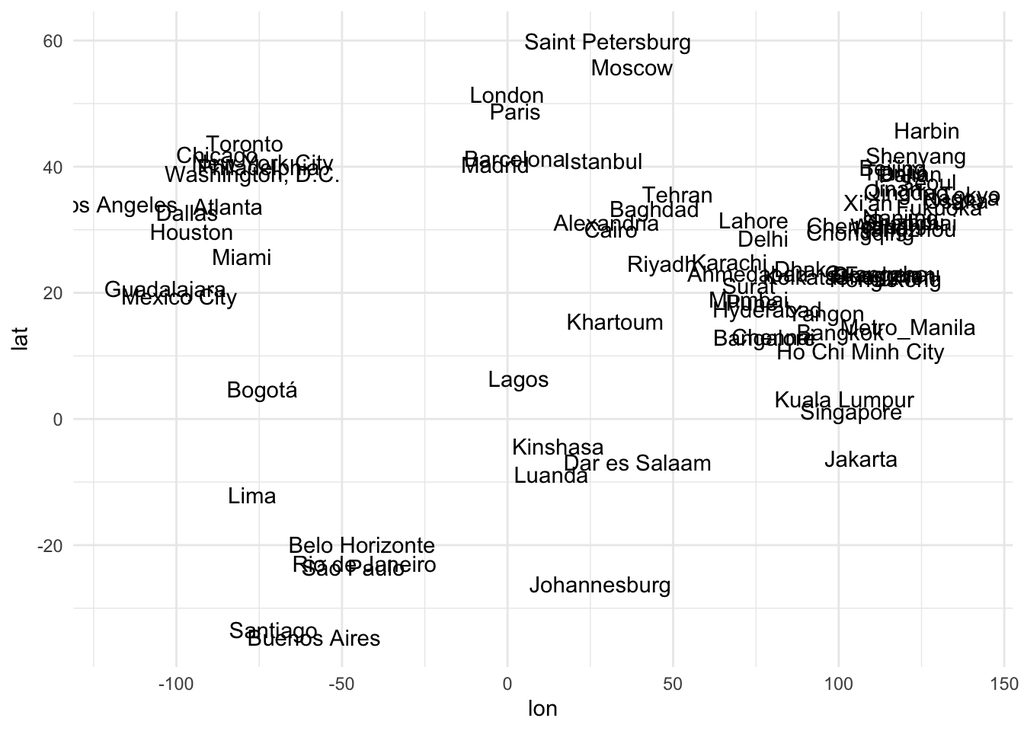

```r
cities %>%
  ggplot() +
    geom_text(aes(x = lon, y = lat, label = name))
```

This should roughly resemble a map of the world. In the code below, produce a modified version of this plot, replacing the text layer with two layers: a text repel layer and well as a point layer.

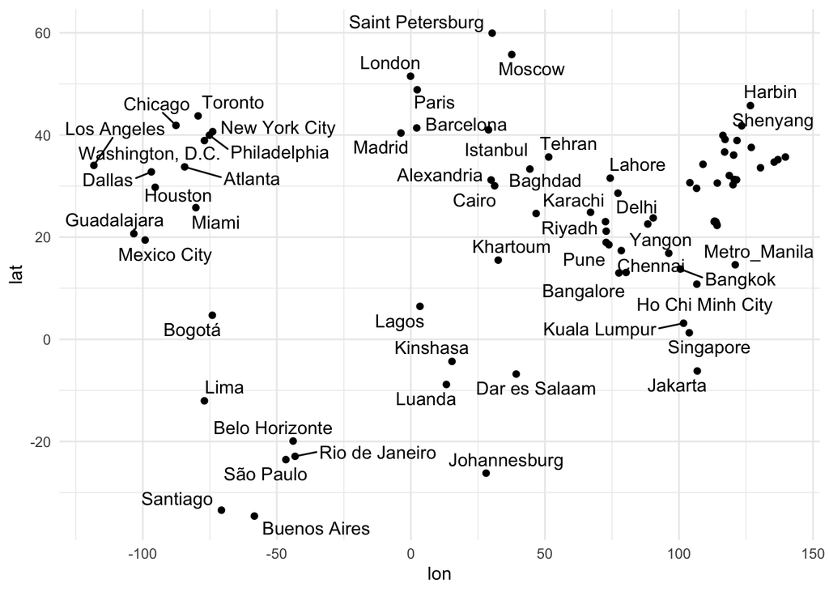

```r
cities %>%
  ggplot() +
    geom_text_repel(aes(x = lon, y = lat, label = name)) +
    geom_point(aes(x = lon, y = lat))
```

Which of these two plots do you find easier to read, and why? (Note, there is no clear correct answer here). **Answer**: I slightly prefer the second, but it would be better to, perhaps, show only a subset of the labels. We will see how to do this soon!